# Part 0: Context

I initially made this presentation for a PyData presentation and have since expanded it. It was made with a technical audience with the following priorities in mind:

## Highest Priority:

- Good model
- Clean code
- Tests for complicated methods or classes

## Lower Priority:

- Efficiency
- Full test coverage

# Part 1: sklearn pipelines and pandas

[figure not shown]

# sklearn pipelines

- Way to string together different steps in the cleaning and modeling process
- Simple Interface: All steps must implement `fit` and `transform`

## `fit`

- sets any variables related to the transform derived from training data
- inputs: training data and target
- output: self

## `transform`

- applies a transformation to incoming data
- inputs: array-like data
- output: transformed array-like data

# Simple Example

Transformation that subsets Dataframe to only the columns listed in subcols

```
class SubsetData(BaseEstimator, TransformerMixin):
    def __init__(self,subcols):
        self.subcols = subcols

    def transform(self, X, **transform_params):
        return X[self.subcols]

    def fit(self, X, y=None, **fit_params):
        return self
```

# BaseEstimator

This class implements `get_params` and `set_params`, which keeps track of parameters associated with the model. This comes in handy when using functionality like GridSearchCV

# TransformerMixin

Implements `fit_transform` so `fit` and `transform` only need to be defined once

# Complex Example

```
class Normalize(BaseEstimator, TransformerMixin):
    def fit(self, X, *args, **kwargs):
        mean_var_dict = {}
        for col in X.columns:
            inarray = X[col]
            mean = np.mean(inarray.values)
            var = np.var(inarray.values)
            mean_var_dict[col]={'mean':mean,"var":var}
        self.mean_var_dict=mean_var_dict
        return self

    def normalize(self, inseries):
        colname = inseries.name
        mean = self.mean_var_dict[colname]['mean']
        var = self.mean_var_dict[colname]['var']
        if var>0:
            normed = (inseries.values-mean)/var
        else:
            normed = inseries.values
        return normed

    def transform(self, X, *args, **kwargs):
        return X.apply(self.normalize, axis=0)
```

# Building a Pipeline

Multiple Transformations can be strung together into a pipeline

```
numeric_cleaning = Pipeline([
        ('subset',SubsetData(numeric+numeric_categorical)),
        ('impute',PandizedTransform(SimpleImputer())),
        ('cap',CapPercentile(upper_percent=99, lower_percent=1)),
        ('norm',Normalize())])
```

# Complex Pipelines with FeatureUnion

Feature generated from distince pipelines can be brought together using FeatureUnion

```
regression_all = Pipeline([
    ('features', PandasFeatureUnion([
            ("categorical", categorical_to_numeric),
            ("numeric", numeric_cleaning),
            ('overallqualsqure', square_overallquality)])),
    ('lasso',lasso_pipeline)
        ])
```

# External Modeling Libraries

```
class ModelTransformer(BaseEstimator, TransformerMixin):
    '''
    Inspired by: http://zacstewart.com/2014/08/05/pipelines-of-featureunions-of-pipelines.html
    '''
    def __init__(self, model, modelname=None):
        self.model = model
        self.modelname = modelname
        self.columns = []

    def fit(self, X, *args, **kwargs):
        self.model.fit(X, *args, **kwargs)
        try:
            self.columns = list(X.columns)
        except AttributeError:
            self.columns = []
        return self

    def transform(self, X, **transform_params):
        if self.modelname is not None:
            outdf = pd.DataFrame(data={self.modelname: self.model.predict(X)},
                                 index=X.index)
        elif isinstance(X, pd.DataFrame) or isinstance(X, pd.Series):
            outdf = pd.Series(data=self.model.predict(X),
                              index=X.index)
        else:
            outdf = pd.DataFrame(self.model.predict(X))
        return outdf

    def predict(self, X):
        return self.model.predict(X)
```

# Are we ready to start modeling?

[figure not shown]

# pandas and sklearn do not always get along

- sklearn started allowing pandas dataframes as inputs with version 0.15 in 2014, most often by extracting the underlying 2-D Numpy Array
- This will break your pipelines if a transformation expects a dataframe and gets a numpy array

# Example: One-Hot Encoding

- Pandas has a one-hot encoder, but it isn't stateful so it can't easily be wrapped to be a transformation
- sklearn has a one-hot encoder, but it isn't built to work with dataframes

# Solution: Build a Pandas-Friendly One-Hot Encoder!

```
class PandasOHE(BaseEstimator,TransformerMixin):
    def fit(self, X, *args, **kwargs):
        new_columns_dict = {}
        left_out_dict = {}
        for col in X.columns:
            inarray = X[col]
            counted = Counter(inarray)
            left_out = counted.most_common()[0][0]
            left_out_dict[col]=left_out
            new_column_mapping = {}
            for value in counted.keys():
                if value == left_out:
                    continue
                new_column_mapping[value]="{}_{}".format(col, str(value))
            new_columns_dict[col] = new_column_mapping
        self.new_columns_dict = new_columns_dict
        self.left_out_dict = left_out_dict
        return self

    def transform(self, X, *args, **transform_params):
        array_of_dfs = []
        for col in X.columns:
            inarray = X[col].values
            col_mapping = self.new_columns_dict[col]
            array_of_dfs.append(pd.DataFrame(index=X.index,
                               data = {val:(key==inarray)
                                       for key,val in col_mapping.items()}))
        return pd.concat(array_of_dfs, axis=1)
```

# Is it worth it?

## Benefits

- Modularizes Code
- Makes it easy to try different combinations of features
- Parameter-optimiation made wasy with GridCVSearch
- Hierarchical Models are trivial

## Drawbacks

- Requires extra time and code
- Requires spending time writing custom transformations for simple operations (I had to write an identity transformation at one point), especially when using pandas
- Learning Curve

# Part 2: Predicting House Prices

# Problem:

Can one predict housing prices in Ames, Iowa as part of [this Kaggle competition?](https://www.kaggle.com/c/house-prices-advanced-regression-techniques)

# Data:

- Data from 1,460 homes sold in Ames, Iowa between 2006 and 2010
- 79 features describing the homes, some categorical, some numeric
- Some missing values (for example, homes without pools have an na in 'PoolQC')

# Goal: Minimize the RMS of the Logs of the Predicted and Actual

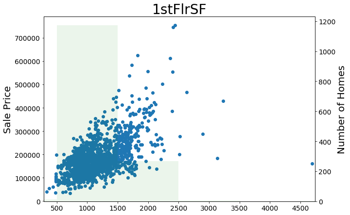

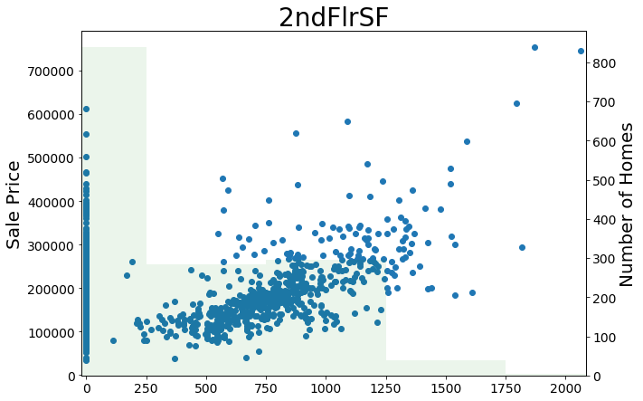

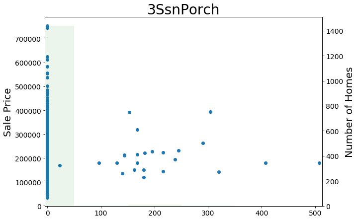

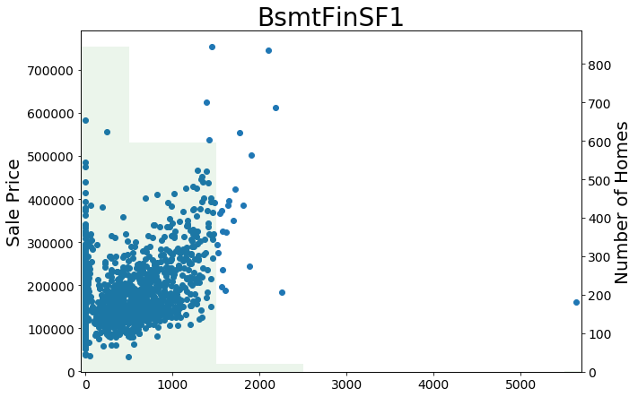

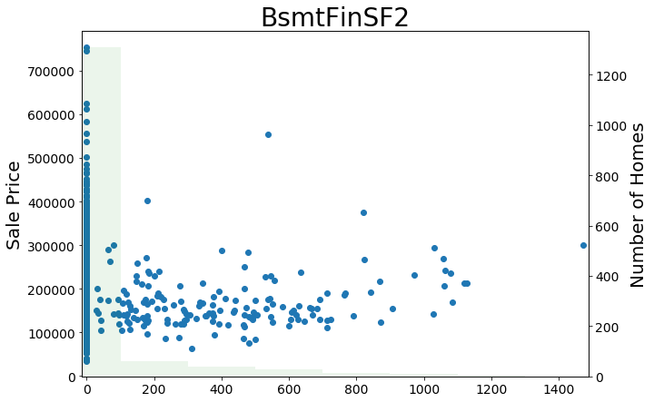

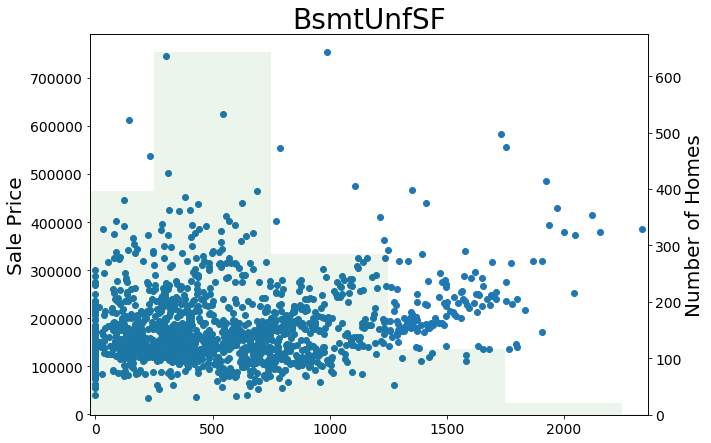

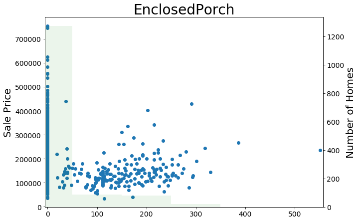

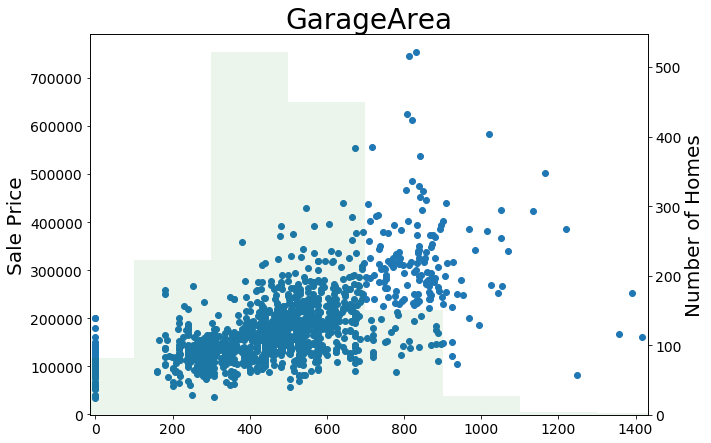

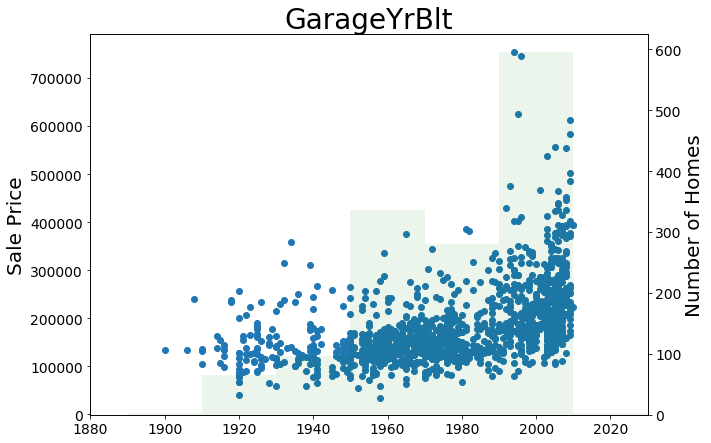

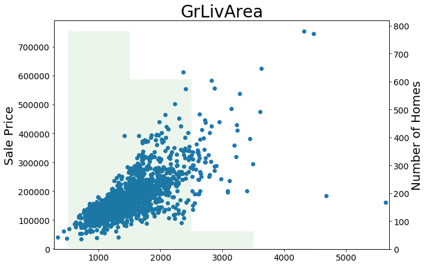

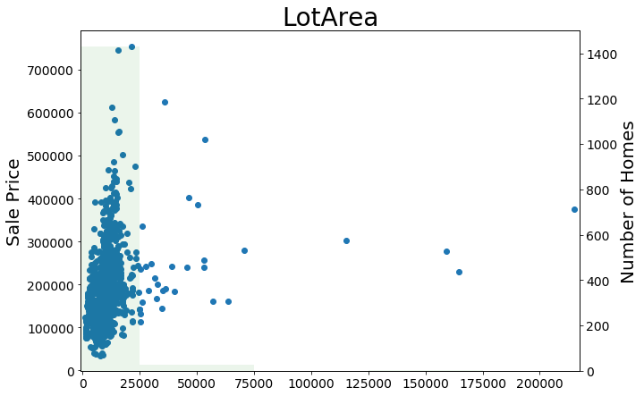

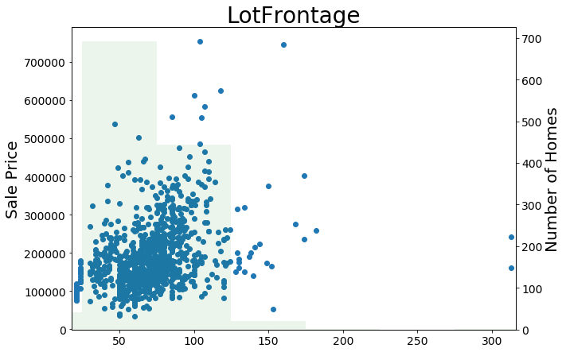

[67 more figures not shown]

```python
for colname in sorted(numeric):
    numeric_univar(data[colname], data['SalePrice'], title=colname)
for colname in sorted(numeric_categorical+ordered_categorical + unordered_categorical):
    cat_univar_bw(data[colname], data['SalePrice'], title=colname)
```

```python
with open("data_description.txt") as infile:
    print("\n".join(infile.readlines()))
```

```
MSSubClass: Identifies the type of dwelling involved in the sale.



        20	1-STORY 1946 & NEWER ALL STYLES

        30	1-STORY 1945 & OLDER

        40	1-STORY W/FINISHED ATTIC ALL AGES

        45	1-1/2 STORY - UNFINISHED ALL AGES

        50	1-1/2 STORY FINISHED ALL AGES

        60	2-STORY 1946 & NEWER

        70	2-STORY 1945 & OLDER

        75	2-1/2 STORY ALL AGES

        80	SPLIT OR MULTI-LEVEL

        85	SPLIT FOYER

        90	DUPLEX - ALL STYLES AND AGES

       120	1-STORY PUD (Planned Unit Development) - 1946 & NEWER

       150	1-1/2 STORY PUD - ALL AGES

       160	2-STORY PUD - 1946 & NEWER

       180	PUD - MULTILEVEL - INCL SPLIT LEV/FOYER

       190	2 FAMILY CONVERSION - ALL STYLES AND AGES



MSZoning: Identifies the general zoning classification of the sale.

```

[output cut: 990 more lines]

```
SaleCondition: Condition of sale



       Normal	Normal Sale

       Abnorml	Abnormal Sale -  trade, foreclosure, short sale

       AdjLand	Adjoining Land Purchase

       Alloca	Allocation - two linked properties with separate deeds, typically condo with a garage unit

       Family	Sale between family members

       Partial	Home was not completed when last assessed (associated with New Homes)
```

```python
nadf = pd.isna(data).sum(axis=0)
nadf[nadf>0]
```

```
LotFrontage      259
Alley           1369
MasVnrType         8
MasVnrArea         8
BsmtQual          37
BsmtCond          37
BsmtExposure      38
BsmtFinType1      37
BsmtFinType2      38
Electrical         1
FireplaceQu      690
GarageType        81
GarageYrBlt       81
GarageFinish      81
GarageQual        81
GarageCond        81
PoolQC          1453
Fence           1179
MiscFeature     1406
dtype: int64
```

# Partitioning the Features

**numeric**: ${\rm I\!R}$-valued  
**numeric_categorical**: $\mathbb{W}$-valued  
**ordered_categorical**: Categories with an inheret ordering, "ExterCond" where categories are  
Ex : Excellent  
Gd : Good  
TA : Average/Typical  
Fa : Fair  
Po : Poor  
**unordered_categorical**: Categories with no inheret ordering, like neighborhood

# Regression Models

## click down for details on models

```python
#Naive Regression with only numeric varibles

regression_pipeline = Pipeline([
    ('model', RegressionTransformer(LinearRegression()))
])

numeric_cleaning = Pipeline([
        ('subset',SubsetData(numeric+numeric_categorical)),
        ('impute',PandizedTransform(SimpleImputer())),
        ('cap',CapPercentile(upper_percent=100, lower_percent=5)),
        ('norm',Normalize())])

generic_regression_numeric = Pipeline([
         ("clean",numeric_cleaning),
        ('regression',regression_pipeline)])

evaluate_model(generic_regression_numeric, "Naive Regression")
```

```
Metric on Training Data: 0.18112
Metric on Test Data: 0.17759
```

```python
#Lasso Regression with only numeric varibles

lasso_pipeline = Pipeline([
    ('model', RegressionTransformer(Lasso(max_iter=10000, alpha=500.), modelname="Lasso"))
])

regression_numeric = Pipeline([
         ("clean",numeric_cleaning),
        ('lasso',lasso_pipeline)])

evaluate_model(regression_numeric, "Naive Lasso")

coefs = regression_numeric.named_steps['lasso'].named_steps['model'].model.coef_
feature_names = regression_numeric.named_steps['lasso'].named_steps['model'].columns
for f,c in sorted(zip(feature_names, coefs), key=lambda x:-x[1]):
    if c>0:
        print(f,c)
```

```
Metric on Training Data: 0.20507
Metric on Test Data: 0.20692


OverallQual 46336.71745842552
TotRmsAbvGrd 22026.768705313534
GarageCars 11947.663945679536
BsmtFullBath 6040.51416360428
FullBath 4351.955748709071
Fireplaces 4203.087421315953
OverallCond 3626.848746828222
HalfBath 1120.0764302617808
BsmtHalfBath 454.25199632312604
```

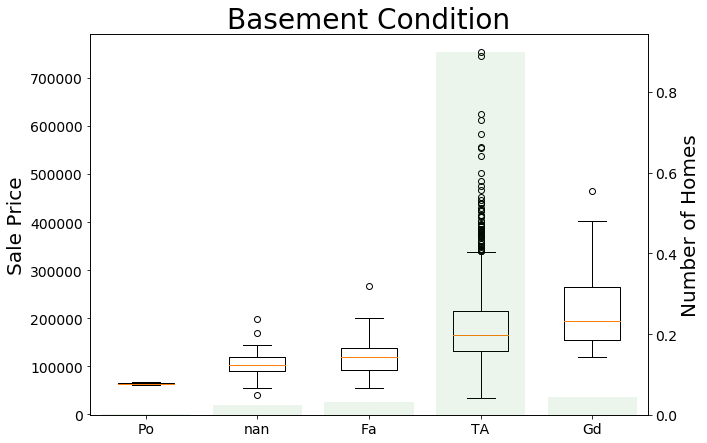

```python
cat_univar_bw(data['BsmtCond'], data['SalePrice'], title="Basement Condition")
```

```
class AssignOrdinals(BaseEstimator, TransformerMixin):
    def __init__(self):
        self.replace_missing_with = -1

    def get_level_mapping(self, column_data, y):
        grouped_target = defaultdict(list)
        for target_el, response_el in zip(column_data, y):
            grouped_target[target_el].append(response_el)
        ordered_keys = sorted(grouped_target.keys(), key=lambda x: np.median(grouped_target[x]))
        return {key: i for i, key in enumerate(ordered_keys)}

    def fit(self, X, y=None, **fit_params):
        self.label_dict = {colname: self.get_level_mapping(X[colname].values, y)
                           for colname in X.columns}
        self.label_values = {colname: list(mapping.values())
                             for colname, mapping in self.label_dict.items()}
        return self

    def check_series_for_missed(self, inseries):
        colname = inseries.name
        try:
            missed = np.isin(inseries.values, self.label_values[colname], invert=True)
        except TypeError:  # column has compativle type with label_values
            # use slower for loop for this case
            missed = [(el in self.label_values[colname]) for el in inseries.values]
        outseries = inseries.copy()
        outseries[missed] = -1
        return outseries

    def transform(self, X, **kwargs):
        X_replaced = X.replace(self.label_dict)
        # replace any strings that were missed due to being a rare level with -1
        X_out = X_replaced.apply(self.check_series_for_missed, axis=0)
        return X_out
```

```python
# Assign numberic value to categorical data
# by ordering by the mean and assigning integer values in order

categorical_to_numeric = Pipeline([
            ('subset',SubsetData(ordered_categorical+unordered_categorical)),
            ("assign_ordinals", AssignOrdinals())])

regression_wcat = Pipeline([
    ('features', PandasFeatureUnion([
            ("categorical", categorical_to_numeric),
            ("numeric", numeric_cleaning)])),
    ('lasso',lasso_pipeline)
        ])

evaluate_model(regression_wcat, "Lasso with Categorical")

coefs = regression_wcat.named_steps['lasso'].named_steps['model'].model.coef_
feature_names = regression_wcat.named_steps['lasso'].named_steps['model'].columns
for f,c in sorted(zip(feature_names, coefs), key=lambda x:-x[1]):
    if c>0:
        print(f,c)
```

```
Metric on Training Data: 0.17099
Metric on Test Data: 0.17121


OverallQual 23343.70405594878
TotRmsAbvGrd 22940.631234233093
ExterQual 8824.18897291462
KitchenQual 8277.636908582172
GarageCars 7872.574937805008
BsmtExposure 6455.142048142437
RoofStyle 5045.504709288165
BsmtQual 4879.653605014055
OverallCond 4565.654438038113
BsmtFullBath 3662.1404584107945
SaleType 2960.640493090517
FireplaceQu 2794.2709956532262
Neighborhood 2390.1757305317137
LandContour 2141.1510436777608
FullBath 2071.5735045726847
HalfBath 1891.1136458125854
SaleCondition 1850.0243068204732
LotConfig 1708.8547762929156
Fireplaces 1656.1073991130008
RoofMatl 1243.4195854641641
Condition1 960.3543052448491
MasVnrType 462.90806382804567
BedroomAbvGr 461.98106293789255
HeatingQC 457.82270220988636
Exterior1st 225.10110369992105
MSSubClass 220.39530734472737
YrSold 167.2223599655916
BsmtHalfBath 89.56794309300682
```

```python
numeric_cols_to_square = ['OverallQual', 'TotRmsAbvGrd',
                          'GarageCars', 'OverallCond']
square_pipeline = Pipeline([
        ('subset',SubsetData(numeric_cols_to_square)),
        ('square', Power(2)),
        ('name', RenameColumns({el:el+"Squared" for el in numeric_cols_to_square}))])

numeric_features_wsquare = Pipeline([('initial_cleaning',numeric_cleaning),
                            ('all_features',PandasFeatureUnion([
                                ('squared',square_pipeline),
                                ('same', IdentityTransformation())
                            ]))])

regression_all = Pipeline([
    ('features', PandasFeatureUnion([
            ("categorical", categorical_to_numeric),
            ("numeric", numeric_features_wsquare)])),
    ('lasso',lasso_pipeline)
        ])

evaluate_model(regression_all, "Lasso with Categorical and Square")

coefs = regression_all.named_steps['lasso'].named_steps['model'].model.coef_
feature_names = regression_all.named_steps['lasso'].named_steps['model'].columns
for f,c in sorted(zip(feature_names, coefs), key=lambda x:-x[1]):
    if c>0:
        print(f,c)
```

```
Metric on Training Data: 0.14945
Metric on Test Data: 0.15287


OverallQual 21081.707719536284
TotRmsAbvGrd 17092.33837368284
OverallQualSquared 15744.590561426014
OverallCond 6423.04221948052
GarageCars 6415.231010684266
BsmtExposure 5655.573435507131
KitchenQual 5571.221021888748
BsmtQual 3944.940001127854
FullBath 3519.2669489959385
RoofStyle 3351.2944917991395
BsmtFullBath 3348.5818725097256
FireplaceQu 2669.993773194878
ExterQual 2664.683047952974
Neighborhood 2524.111143739043
HalfBath 2437.4994807188727
LotConfig 2394.9959194217386
SaleCondition 2312.918863136012
GarageCarsSquared 2298.223396104792
SaleType 2206.83032256879
RoofMatl 2150.019275022865
Fireplaces 2134.1535457613777
GarageCond 1855.2235102835004
BedroomAbvGr 1493.248520865172
Condition1 1366.5332918185845
HeatingQC 1109.3597151154931
GarageType 929.6744069908618
LandContour 868.5022045014744
MSSubClass 676.1864731539442
GarageQual 417.04784468621534
Exterior1st 414.45361451975214
BsmtHalfBath 198.26667746083405
TotRmsAbvGrdSquared 162.72937332111596
```

# Lasso Parameter Optimization

```
parameters = {"lasso__model__model__alpha":range(100,800,100),
              'features__numeric__initial_cleaning__cap__lower_percent':[0,5,10,15],
              'features__numeric__initial_cleaning__cap__upper_percent':[100,95,90],
             'features__numeric__all_features__squared__subset__subcols':[numeric_in_lasso[:i]
                                                                          for i in range(1,len(numeric_in_lasso))]}
regression_all_lasso = GridSearchCV(regression_all, parameters, cv=2,
                   scoring=make_scorer(compute_metric, greater_is_better=False),
                  n_jobs=-1, return_train_score=True,verbose=5)
regression_all_lasso.fit(train, train['SalePrice'])
```

## Results:

- alpha: 500
- lower cap: 5%
- upper cap: 100% (no cap)
- numeric variables to square:  
  OverallQual  
  TotRmsAbvGrd  
  OverallCond  
  GarageCars

```python
# Regression with PCA
numeric_cleaning_pca = Pipeline([
        ('subset',SubsetData(numeric+numeric_categorical)),
        ('impute',PandizedTransform(SimpleImputer())),
        ('cap',CapPercentile(upper_percent=95, lower_percent=5)),
        ('norm',Normalize())])

numeric_features_wsquare_pca = Pipeline([('initial_cleaning',numeric_cleaning_pca),
                            ('all_features',PandasFeatureUnion([
                                ('squared',square_pipeline),
                                ('same', IdentityTransformation())
                            ]))])

pca_all = Pipeline([
    ('features', PandasFeatureUnion([
            ("categorical", categorical_to_numeric),
            ("numeric", numeric_features_wsquare_pca)])),
    ('pca',PandasPCA(PCA(n_components=81))),
    ('normal',regression_pipeline)
        ])

evaluate_model(pca_all, "Regression with Cat, Square, and PCA")
```

```
Metric on Training Data: 0.13882
Metric on Test Data: 0.15543
```

# PCA Regression Optimization

```
parameters = {'pca__pcainstance__n_components':range(1,85,4),
              'features__numeric__initial_cleaning__cap__lower_percent':[0,5,10,15],
              'features__numeric__initial_cleaning__cap__upper_percent':[100,95,90]}
pca_search = GridSearchCV(pca_all, parameters, cv=2,
                   scoring=make_scorer(compute_metric, greater_is_better=False),
                  n_jobs=-1,verbose=2)
pca_search.fit(train,train['SalePrice'])
```

## Results

- lower cap: 5%
- upper cap: 95%
- number of components: 81

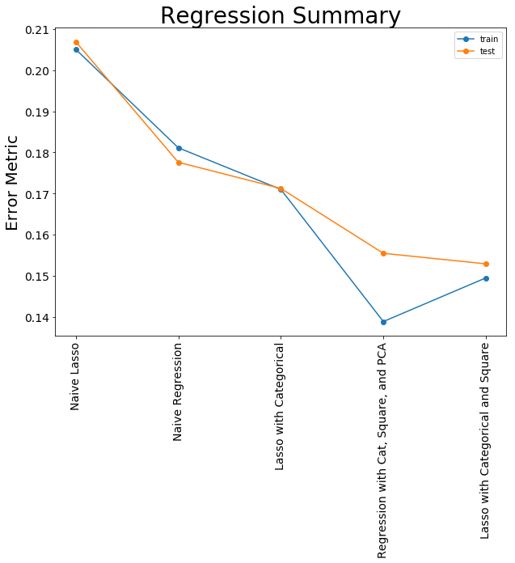

```python
plot_results(title="Regression Summary")
```

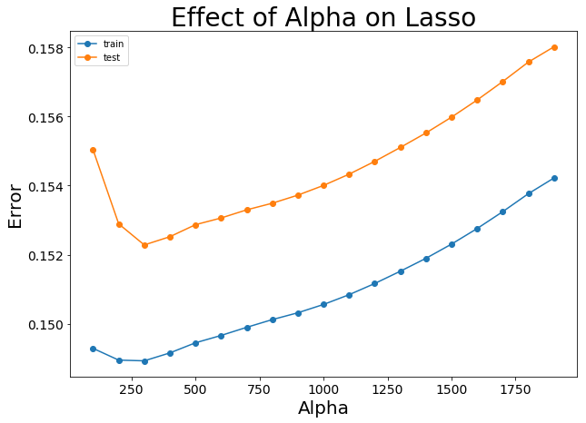

```python
test_array = []
train_array = []
alpha_array = range(100,2000,100)
regression_all_inloop = clone(regression_all)
for alpha in alpha_array:
    regression_all_inloop.set_params(lasso__model__model__alpha=alpha)
    train_pred = regression_all_inloop.fit_transform(train, train['SalePrice'])
    train_metric = compute_metric(train_pred, train['SalePrice'])
    test_pred = regression_all_inloop.transform(test)
    test_metric = compute_metric(test_pred, test['SalePrice'])
    test_array.append(test_metric)
    train_array.append(train_metric)
plt.plot(alpha_array,train_array,'-o',label="train")
plt.plot(alpha_array,test_array,'-o',label="test")
plt.legend()
plt.title("Effect of Alpha on Lasso")
plt.xlabel("Alpha")
plt.ylabel("Error")
plt.show()
```

# Gradient Boosted Trees

## click down for details on models

```python
numeric_cleaning_tree = Pipeline([
        ('subset',SubsetData(numeric+numeric_categorical)),
        ('impute',PandizedTransform(SimpleImputer())),
        ('cap',CapPercentile(upper_percent=98, lower_percent=2))])

category_cleaning_tree = Pipeline([
        ('subset',SubsetData(ordered_categorical+unordered_categorical)),
          ('get_dummies',PandasOHE())])



pipeline_features = PandasFeatureUnion([
    ('categorical', category_cleaning_tree),
    ('numeric', numeric_cleaning_tree)
  ])


pipeline_xgboost_simple = Pipeline([
        ('features',pipeline_features),
        ('fittree',
         ModelTransformer(xgb.XGBRegressor(max_depth=3,
                                           n_estimators=5000,
                                           learning_rate=0.025,colsample_bytree=0.15,
                                          random_state=1990,
                                          n_jobs=-1))),
])

evaluate_model(pipeline_xgboost_simple, "Simple GBM")
```

```
Metric on Training Data: 0.01972
Metric on Test Data: 0.12024
```

# GBM Parameter Optimization

```
parameters = {'fittree__model__max_depth':[1,3,5],
              'fittree__model__n_estimators':[1000,5000,7500],
              'fittree__model__colsample_bytree':[.05,.075,.10,.15],
                "fittree__model__learning_rate":[.01,.025,.05]}
xgb_search = GridSearchCV(pipeline_xgboost_simple, parameters, cv=2,
                   scoring=make_scorer(compute_metric, greater_is_better=False),
                  n_jobs=-1,verbose=2)
xgb_search.fit(train,train['SalePrice'])
```

## Results

max_depth: 3  
n_estimators: 5000  
colsample_bytree: .15  
learning_rate: .025

```python
pipeline_features_xgb = PandasFeatureUnion([
    ('categorical', category_cleaning_tree),
    ('numeric', numeric_cleaning_tree),
    ('lasso',regression_all)
  ])


pipeline_xgboost_lasso = Pipeline([
        ('features',pipeline_features_xgb),
        ('fittree',
         ModelTransformer(xgb.XGBRegressor(max_depth=3,
                                           n_estimators=5000,
                                           learning_rate=0.025,colsample_bytree=0.15,
                                          random_state=1990,
                                          n_jobs=-1))),
])

evaluate_model(pipeline_xgboost_lasso, "GBM with Lasso as input")
```

```
Metric on Training Data: 0.01922
Metric on Test Data: 0.11838
```

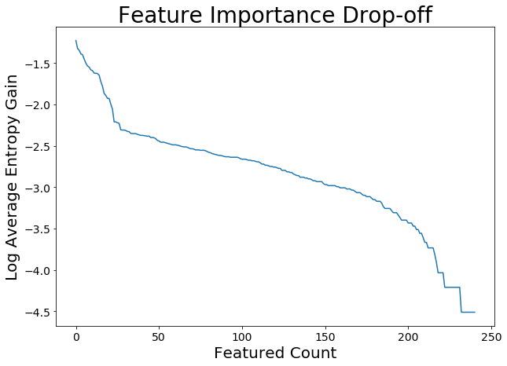

```python
plt.plot(importance_val)
plt.xlabel("Featured Count")
plt.ylabel("Log Average Entropy Gain")
plt.title("Feature Importance Drop-off")
plt.show()
```

# Parameter Optimization for Feature Importance

```
parameters = {'fittree__model__max_depth':[1,3,5],
              'fittree__model__colsample_bytree':[.25,.5,.75],
              'fittree__model__n_estimators':[500,1000,2000],
              'fittree__model__learning_rate':[.05,.1],
              'reduceFeatures__subcols':[ordered_cols[:maxcols] for maxcols in range(20,190,30)]}
xgb_red_search = GridSearchCV(pipeline_xgboost_red, parameters, cv=2,
                   scoring=make_scorer(compute_metric, greater_is_better=False),
                  n_jobs=-1,verbose=5)
xgb_red_search.fit(train,train['SalePrice'])
```

```python
xgboost_lasso_sub = ModelTransformer(xgb.XGBRegressor(max_depth=3,
                                           n_estimators=1000,
                                           learning_rate=0.05,colsample_bytree=0.5,
                                          random_state=1990,
                                          n_jobs=-1), modelname='xgb_value')

pipeline_xgboost_red = Pipeline([
        ('features',pipeline_features_xgb),
        ('reduceFeatures',SubsetData(ordered_cols[:140], safe=True)),
        ('fittree',xgboost_lasso_sub)
])

evaluate_model(pipeline_xgboost_red, "GBM with Lasso and feature selection")
```

```
Metric on Training Data: 0.04033
Metric on Test Data: 0.11723
```

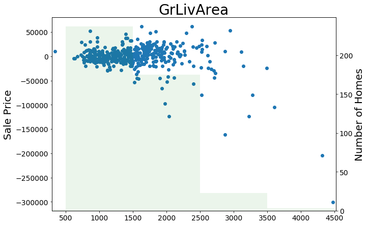

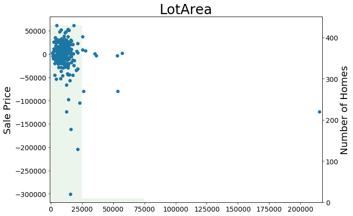

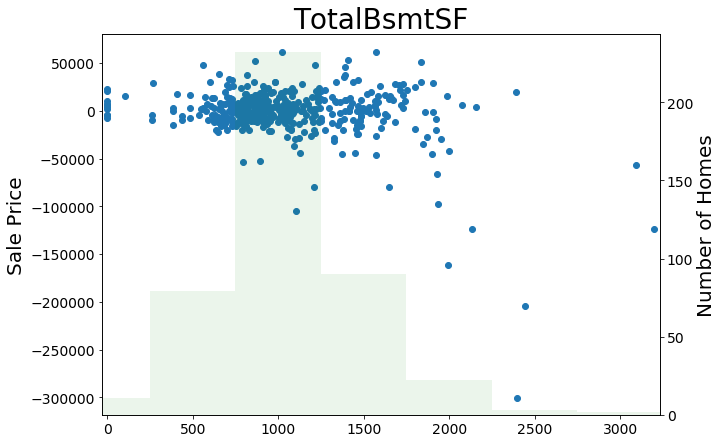

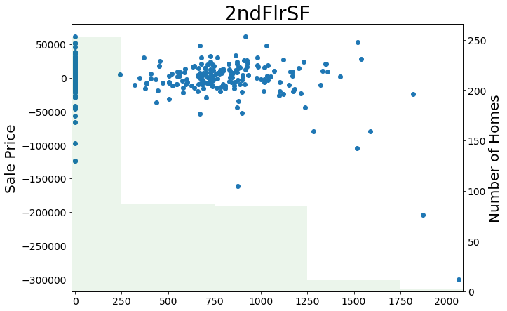

```python
test_preds = pipeline_xgboost_red.transform(test)
residuals = test_preds['xgb_value']-test['SalePrice']
for colname in ['GrLivArea','LotArea','TotalBsmtSF','2ndFlrSF']:
    numeric_univar(test[colname], residuals, title=colname)
```

# Using Decision Trees to Engineer Features

I noticed some points with very high residuals that appeared to have some traits in common. I built a decision tree fit on high-residual points to help engineer features to better predict them

```
from sklearn.tree import DecisionTreeClassifier, export_graphviz
test_features = pipeline_features.transform(test)
dtree = DecisionTreeClassifier(class_weight = {1:len(test)/13, 0:1}, max_leaf_nodes=5)
dtree.fit(test_features, residuals<-50000)
export_graphviz(dtree, out_file="images/tree1.png", feature_names = test_features.columns)
```

[figure not shown]

# Using Decision Trees to Engineer Features (cont)

Remove the columns used in the tree above and repeat

```
test_features = pipeline_features.transform(test).copy()
test_features.drop(columns=['LotArea','GrLivArea','Lasso'],inplace=True)
dtree = DecisionTreeClassifier(class_weight = {1:len(test)/13, 0:1}, max_leaf_nodes=5)
dtree.fit(test_features, residuals<-50000)
export_graphviz(dtree, out_file="images/tree2.png", feature_names = test_features.columns)
```

[figure not shown]

```python
bighouse_pipeline = Pipeline([
    ('subset', SubsetData(['GrLivArea','LotArea'])),
    ('threshold', StrictlyGreaterThan({'GrLivArea':1930.5, 'LotArea':12350.5})),
    ('and', MultiplyColumns(['GrLivArea','LotArea'], 'bighouse', replace=True))
])

bigbasement_pipeline = Pipeline([
    ('subset', SubsetData(['TotalBsmtSF','2ndFlrSF'])),
    ('threshold', StrictlyGreaterThan({'TotalBsmtSF':1644., '2ndFlrSF':892.})),
    ('and', MultiplyColumns(['TotalBsmtSF',  '2ndFlrSF'], 'bigbasement', replace=True))
])

pipeline_xgboost_bighouse = Pipeline([
        ('features',PandasFeatureUnion([
            ('original_features',Pipeline([
                ('features',pipeline_features_xgb),
                ('reduceFeatures',SubsetData(ordered_cols[:138], safe=True))])),
            ('bighouse_pipeline',bighouse_pipeline),
            ('bigbasement_pipeline',bigbasement_pipeline)])),
        ('fittree',xgboost_lasso_sub)
])

evaluate_model(pipeline_xgboost_bighouse, "GBM with Lasso, feature selection, bighouse")
```

```
Metric on Training Data: 0.04092
Metric on Test Data: 0.11622
```

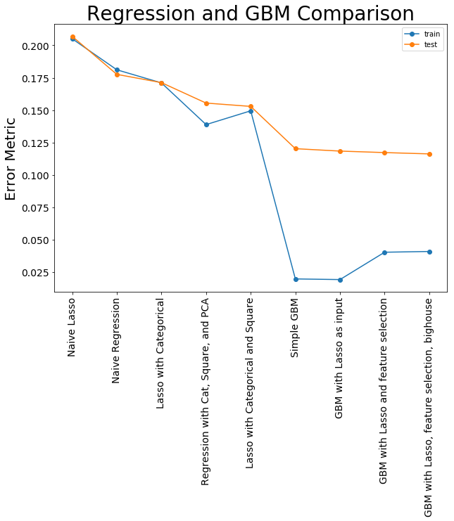

```python
plot_results(title="Regression and GBM Comparison")
```